# Wine Reviews

2026-02-26

## Introduction

Link to dataset: https://www.kaggle.com/datasets/zynicide/wine-reviews

country: Country where the wine was produced

province: Province or state of origin

price: Price of the wine (USD)

points: Quality rating score (80–100 scale)

variety: Type of grape

winery: Winery name

description: Text description of the wine

Description of motivation for studying dataset: I chose this dataset because I was curious about whether expensive wines really score higher than cheaper ones. I wanted to find out if you actually “get what you pay for” when buying wine and whether some countries tend to produce higher-rated wines than others.

Summary: The dataset contains approximately 130,000 wine reviews, with each observation representing a single wine. The main quantitative variables are price (in U.S. dollars) and points (rating on a scale from 80 to 100). The average wine price is around $35, while the median price is about $25. Wine ratings range from 80 to 100 points, with an average and median of about 88 points, showing that most wines receive relatively high and closely clustered ratings.

## Visualizations

One plot showing the relationship between two quantitative variables in the dataset, along with interpretation:

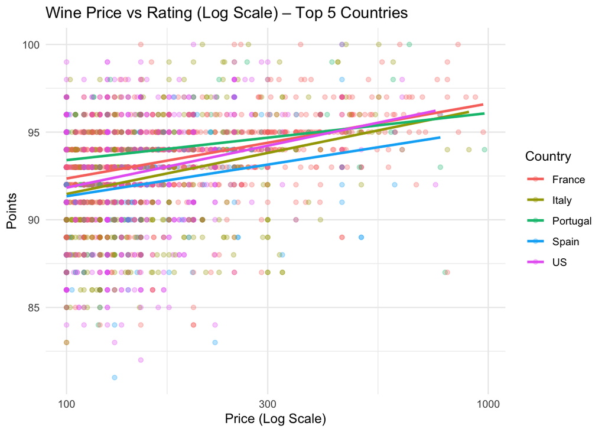

```r
top_5_countries <- wine %>%
  count(country) %>%
  arrange(desc(n)) %>%
  slice_head(n = 5) %>%
  pull(country)

scatter_plot <- wine %>%
  filter(!is.na(price),
         country %in% top_5_countries,
         price >= 100,
         price < 1000) %>%
  ggplot(aes(x = price, y = points, color = country)) +
  geom_point(alpha = 0.3) +
  geom_smooth(method = "lm", se = FALSE) +
  scale_x_log10() +
  labs(
    title = "Wine Price vs Rating (Log Scale) – Top 5 Countries",
    x = "Price (Log Scale)",
    y = "Points",
    color = "Country"
  ) +
  theme_minimal()

scatter_plot
```

Interpretation: For the top five countries, wine points generally increase with price, but the effect is small. Most wines are rated between 88 and 95 points, so paying more doesn’t always mean a much better score. The regression lines are similar across countries, showing that the price-quality relationship is fairly consistent.

One plot showing the relationship between a categorical and quantitative variable in the dataset, along with interpretation:

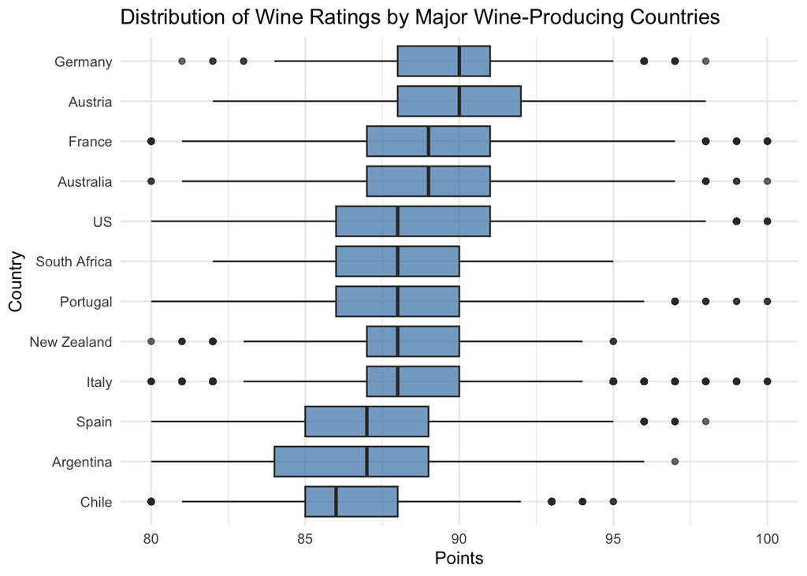

```r
major_countries <- wine %>%
  count(country) %>%
  filter(n >= 1000) %>%
  pull(country)

box_plot <- wine %>%
  filter(country %in% major_countries) %>%
  ggplot(aes(x = reorder(country, points, median), y = points)) +
  geom_boxplot(fill = "steelblue", alpha = 0.7) +
  coord_flip() +
  labs(
    title = "Distribution of Wine Ratings by Major Wine-Producing Countries",
    x = "Country",
    y = "Points"
  ) +
  theme_minimal()

box_plot
```

## Dataset manipulations

One plot based on a dplyr manipulation of the dataset:

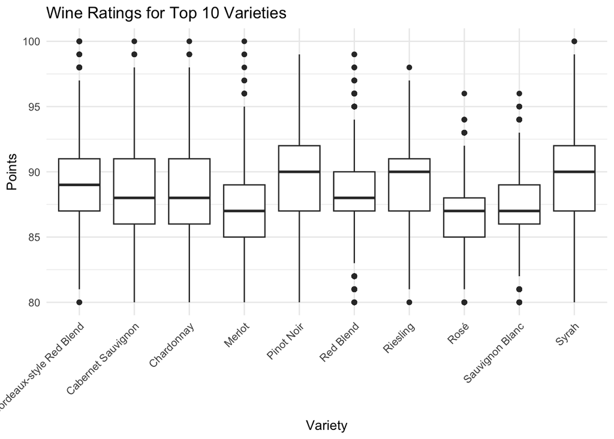

```r
top_varieties <- wine %>%
  count(variety, sort = TRUE) %>%
  slice_head(n = 10) %>%
  pull(variety)

wine_top_varieties <- wine %>%
  filter(variety %in% top_varieties,
         !is.na(points))

ggplot(wine_top_varieties, aes(x = variety, y = points)) +
  geom_boxplot() +
  labs(
    title = "Wine Ratings for Top 10 Varieties",
    x = "Variety",
    y = "Points"
  ) +
  theme_minimal() +
  theme(axis.text.x = element_text(angle = 45, hjust = 1))
```

Interpretation: Filtering to the most common varieties makes it easier to compare rating distributions. Some varieties show higher median scores and less variability, while others have wider spreads. This reveals that wine ratings differ meaningfully by grape variety, a pattern that is harder to see in the full dataset.

## Statistical analysis

One correlation between two quantitative variables in the dataset, and interpretation of the result:

```r
wine %>%
  filter(!is.na(price), !is.na(points)) %>%
  with(cor.test(price, points))
```

```
##
##  Pearson's product-moment correlation
##
## data:  price and points
## t = 159.19, df = 120973, p-value < 2.2e-16
## alternative hypothesis: true correlation is not equal to 0
## 95 percent confidence interval:
##  0.4114967 0.4208150
## sample estimates:
##       cor
## 0.4161667
```

Interpretation: There is a positive relationship between the price of a wine and its points (quality rating). The correlation coefficient is about 0.42, which means that more expensive wines tend to have higher points. However, the relationship is moderate, not perfect, so price alone doesn’t fully determine quality.

One linear regression between two quantitative variables in the dataset, and interpretation of the result:

```r
model <- lm(points ~ price, data = wine)
summary(model)
```

```
##
## Call:
## lm(formula = points ~ price, data = wine)
##
## Residuals:
##      Min       1Q   Median       3Q      Max
## -101.254   -1.793    0.053    2.003   10.311
##
## Coefficients:
##              Estimate Std. Error t value Pr(>|t|)
## (Intercept) 87.329638   0.010509  8310.4   <2e-16 ***
## price        0.030886   0.000194   159.2   <2e-16 ***
## ---
## Signif. codes:  0 '***' 0.001 '**' 0.01 '*' 0.05 '.' 0.1 ' ' 1
##
## Residual standard error: 2.768 on 120973 degrees of freedom
##   (8996 observations deleted due to missingness)
## Multiple R-squared:  0.1732, Adjusted R-squared:  0.1732
## F-statistic: 2.534e+04 on 1 and 120973 DF,  p-value: < 2.2e-16
```

Interpretation: The linear regression shows that there is a small but statistically significant relationship between wine price and points. On average, each additional dollar in price is associated with an increase of about 0.03 points. However, price only explains a small amount of the variation in wine ratings, meaning most of the differences in points come from other factors like grape variety or region. More expensive wines tend to score slightly higher, but price alone is not a strong predictor of quality.

One t-test between a categorical and quantitative variable in the dataset, and interpretation of the result:

```r
wine <- subset(wine, country %in% c("France", "Italy"))
t_result <- t.test(points ~ country, data = wine)
print(t_result)
```

```
##
##  Welch Two Sample t-test
##
## data:  points by country
## t = 10.136, df = 41620, p-value < 2.2e-16
## alternative hypothesis: true difference in means between group France and group Italy is not equal to 0
## 95 percent confidence interval:
##  0.2281780 0.3375779
## sample estimates:
## mean in group France  mean in group Italy
##             88.84511             88.56223
```

Interpretation: The Welch Two Sample t-test compares wine points between France and Italy. The average points for French wines is about 88.85, while Italian wines average 88.56. The difference is small but statistically significant (p-value < 0.001), and the 95% confidence interval (0.23 to 0.34) shows that French wines tend to score slightly higher than Italian wines.